# PAC Analysis

## Introduction

This project aims to examine the impact of foreign-connected Political Action Committee (PAC) donations on US politics from 2000 to 2024. Specifically, it will analyze the possible correlation between the contributions made by PACs affiliated with foreign companies or entities to Democratic and Republican seats in Congress to the presidential election results. The ultimate goal is to determine whether there is a relationship between Foreign PAC Donations and US political results, and if so, to understand the extent to which such donations influence political outcomes and partisan dynamics in the United States.

## Data Methodology

### OpenSecrets

For OpenSecrets Dataset (Raw: 2636 Rows; No NAs; Predictors: PAC Donation amount):

```
# A tibble: 2,636 × 6
   `PAC Name (Affiliate)`        Country of Origin/Pa…¹ Total Dems  Repubs  year
   <chr>                         <chr>                  <chr> <chr> <chr>  <dbl>
 1 7-Eleven                      Japan/Ito-Yokado       $8500 $1500 $7000   2000
 2 ABB Group                     Switzerland/Asea Brow… $460… $170… $28500  2000
 3 Accenture                     UK/Accenture plc       $759… $230… $52984  2000
 4 ACE INA                       UK/ACE Group           $385… $125… $26000  2000
 5 Acuson Corp (Siemens AG)      Germany/Siemens AG     $2000 $2000 $0      2000
 6 Adtranz (DaimlerChrysler)     Germany/DaimlerChrysl… $105… $100… $500    2000
 7 AE Staley Manufacturing (Tat… UK/Tate & Lyle         $240… $100… $14000  2000
 8 AEGON USA (AEGON NV)          Netherlands/Aegon NV   $582… $105… $47750  2000
 9 AIM Management Group          UK/AMVESCAP            $250… $100… $15000  2000
10 Air Liquide America           France/L'Air Liquide … $0    $0    $0      2000
# ℹ 2,626 more rows
# ℹ abbreviated name: ¹`Country of Origin/Parent Company`
```

After some data wrangling and processing, the ultiamte PAC dataset that will be analyze upon looks like following:

```
# A tibble: 286 × 5
   country   dems_sum repubs_sum total_sum year_cycle
   <chr>        <dbl>      <dbl>     <dbl>      <dbl>
 1 Australia    61850     174000    235850       2000
 2 Australia    70019      42333    112352       2002
 3 Australia   137969     113498    252705       2004
 4 Australia    21088       8500     29588       2006
 5 Australia    25158      13750     38908       2008
 6 Australia    32376      17000     49376       2010
 7 Australia    53353      24500     77853       2012
 8 Australia    31655      44100     75755       2014
 9 Australia    39285      92200    131485       2016
10 Australia    35601     116506    152107       2018
# ℹ 276 more rows
```

### Congressional Distribution by Parties

For Wikipedia Dataset (Raw: 118 Rows; No NAs; Target Variable: Seats by Parties):

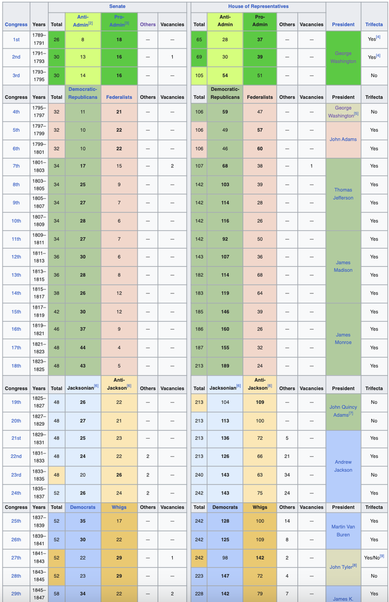

Wikipedia Screenshot

- The dataset provides a record of the party divisions within the United States Congress since 1789 through various congressional sessions.
- It includes columns such as Congress, Years, Senate composition (Total, Anti-Administration, Pro-Administration, Others, Vacancies), House of Representatives composition (Total, Anti-Administration, Pro-Administration, Others, Vacancies), President, and Trifecta status. Each row corresponds to a specific congressional session, detailing the composition of the Senate and House of Representatives, any presidential affiliations, and whether a trifecta scenario was present.
- Data types in the dataset include integers for numerical values such as the total number of seats and vacancies, strings for textual information such as the President’s name, and categorical variables for party affiliations.

Similarly, the ultiamte Congress Parties dataset that will be analyze upon looks like following:

```
# A tibble: 13 × 5
    year democratic_senate_1 republican_senate_1 democratic_house_1
   <dbl>               <dbl>               <dbl>              <dbl>
 1  2000                  45                  55                211
 2  2002                  50                  50                212
 3  2004                  48                  51                205
 4  2006                  44                  55                202
 5  2008                  49                  49                233
 6  2010                  56                  40                257
 7  2012                  51                  47                193
 8  2014                  53                  45                201
 9  2016                  44                  54                188
10  2018                  46                  52                194
11  2020                  45                  53                235
12  2022                  48                  50                222
13  2024                  48                  49                213
# ℹ 1 more variable: republican_house_1 <dbl>
```

## Analysis

### Overview of PAC Influence on US Congress Representation

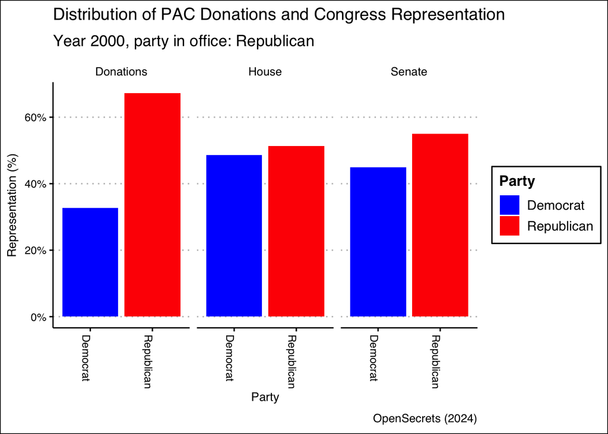

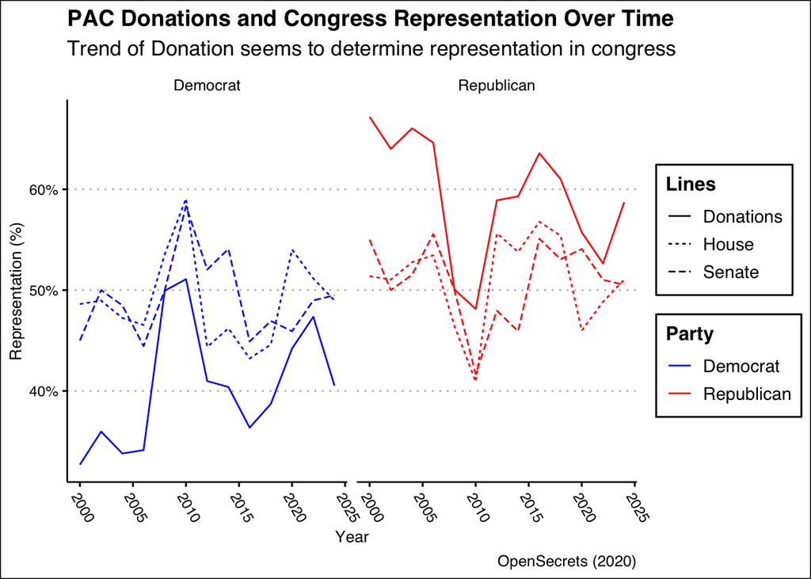

Correlation Between House of Representative and Donation Percentages: Republican: **0.745** Democratic: **0.736**

Correlation Between Senate and Donation Percentages: Republican: **0.612** Democratic **0.604**

From the plots, it seems that the party representation in Congress almost parallels the trend of foreign-connected PAC donations.

In fact, looking closely, the trend of donations seem the predict the representation as the changes in donations happen earlier than the changes in representation.

### PAC by Countries/Regions

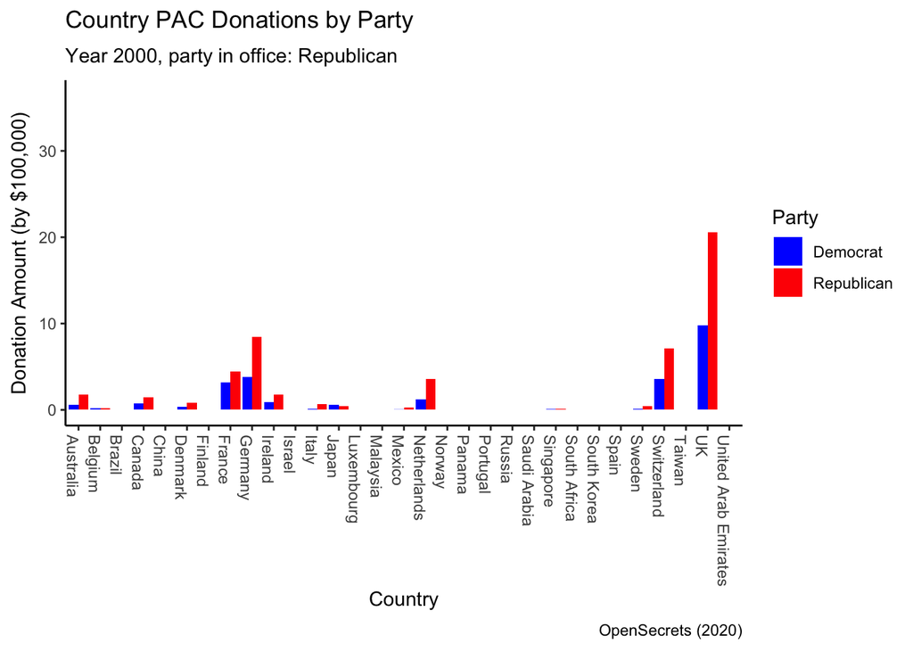

## Election Prediction Using PAC Donations

### Visualization

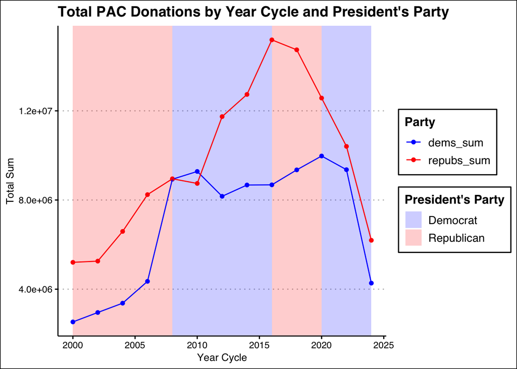

This graph illustrates the total sum of PAC donations received by Democratic and Republican candidates over different election cycles from 2000 to 2024. The donations are represented by blue lines for Democrats (dems_sum) and red lines for Republicans (repubs_sum). The background shading indicates the president’s party during each period, with blue representing Democratic presidencies and red representing Republican presidencies.

Observation: - From 2000 to around 2008, Republican PAC donations were consistently higher than Democratic donations, reflecting stronger Republican fundraising during this period.

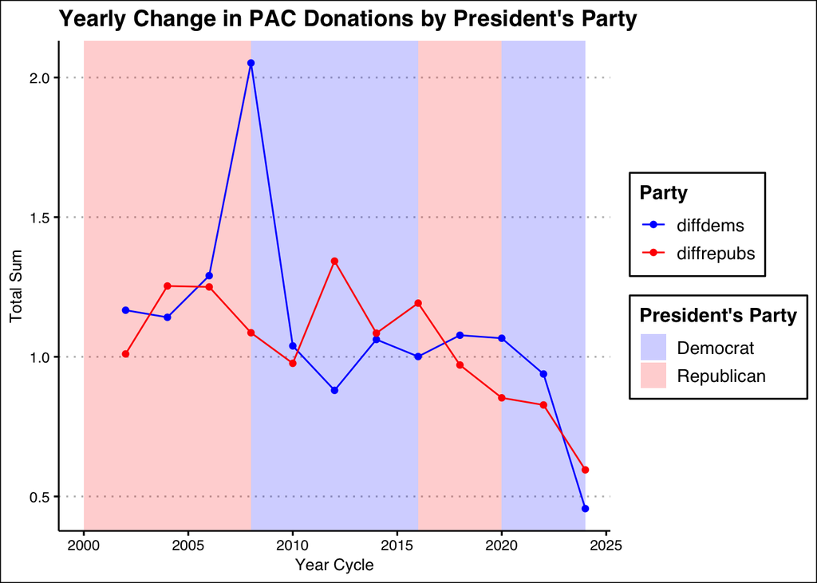

### Model Creation

This model aims to predict the political party of the president for the year 2024 using historical data on political contributions from 2000 to 2024, with training limited to data up to 2012. The process begins by loading necessary libraries for data manipulation and machine learning. Historical data is then prepared by calculating the lagged values of contributions, which represent contributions from the previous cycle, and computing the ratios of current to lagged contributions to capture relative changes. A Random Forest classifier is trained on this processed data, using the election cycle, sums of contributions for each party, and the computed ratios as predictor variables. For the 2024 prediction, a new dataset is created with projected contribution sums, and ratios are calculated based on the latest available training data. The trained model then predicts the political party of the president for 2024 based on this new data. The final output includes the year, projected contribution sums, calculated ratios, and the predicted political party. This model leverages historical trends and relative changes in political contributions to forecast the political outcome for the 2024 presidential election.

| Year Cycle | Democratic Sum | Republican Sum | Democratic Ratio | Republican Ratio | Predicted President Party |
| --- | --- | --- | --- | --- | --- |
| 2024 | 4272336 | 6192659 | 0.5231894 | 0.5274752 | Republican |

The prediction for the 2024 presidential election indicates that the Republican Party is expected to win. This is based on a Random Forest model that used data from previous election cycles. The data shows that the Democratic contributions sum to 4,272,336, while the Republican contributions sum to 6,192,659. The ratios of current to previous contributions are 0.523 for Democrats and 0.527 for Republicans, suggesting a slightly higher momentum for the Republicans, leading to the predicted outcome.

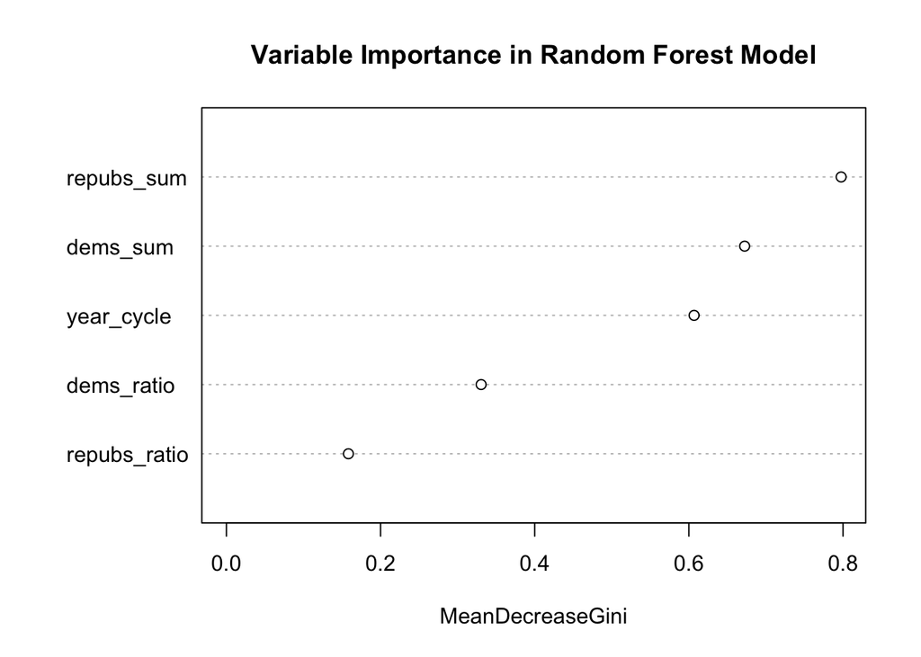

This graph illustrates the variable importance in a Random Forest model by showing the contribution of each variable to the model’s predictive performance. It uses the “Mean Decrease Gini” score to quantify the influence of each factor, with a higher score indicating a more influential variable.

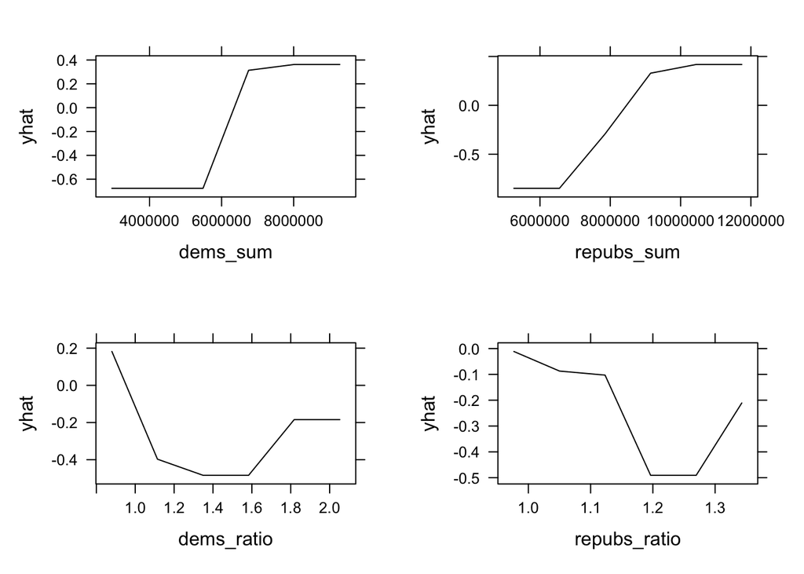

These plots show the partial dependence of different variables in the model on the model’s predictions. Each plot represents how a specific variable, such as “dems_sum,” “repubs_sum,” “dems_ratio,” and “repubs_ratio”, influences the model’s output while keeping all other variables constant.